# Bayesian Modeling and prediction for movies

## Setup

### Load packages

```r
library(ggplot2)
library(dplyr)
library(statsr)
library(BAS)
library(broom)
library(MASS)
library(GGally)
```

### Load data

```r
load("movies.Rdata")
```

## Part 1: Data

It is simply stated that the boss has acquired the data and that a random sample of movies is selected from the population of movies on IMDB & Rotten Tomatoes. The sampling methods are not clearly stated and cannot be further inquired within this hypothetical scenario, so we must accept this to be true.

As the sample is random, any of the statistical results can be generalized to the entire population of movies on IMDB & Rotten Tomatoes.

The study is an observational study, and therefore can suggest correlation, but cannot infer causality. Only a controlled experiment with random assignment could infer causality.* * *

## Part 2: Data manipulation

The mutate function from the dplyr package is used below to create 5 new variables.

```r
  movies <- movies %>%
  mutate(feature_film = ifelse(title_type == "Feature Film", "yes", "no")) %>%
  mutate(drama = ifelse(genre == "Drama", "yes", "no")) %>%
  mutate(mpaa_rating_R = ifelse(mpaa_rating == "R", "yes", "no")) %>%
  mutate(oscar_season = ifelse(thtr_rel_month == "10" | thtr_rel_month == "11" | thtr_rel_month == "12", "yes", "no")) %>%
  mutate(summer_season = ifelse(thtr_rel_month == "5" | thtr_rel_month == "6" | thtr_rel_month == "7" | thtr_rel_month == "8", "yes", "no"))
```

## Part 3: Exploratory data analysis

Firstly we will plot a histogram of audience score to understand the distribution. The distribution is left skewed, with the most common audience scores around 80, and a small peak around 50 also. We can see from the numerical summary that the range of scores is 11 to 97.

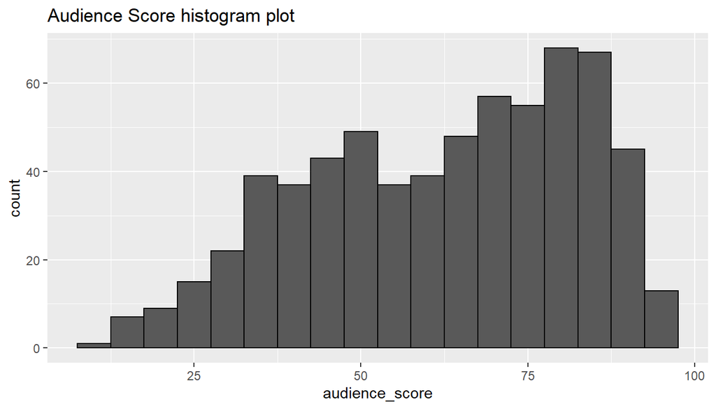

```r
  ggplot(data = movies, aes(x = audience_score)) +
  geom_histogram(binwidth=5, color="black") +
  labs(title="Audience Score histogram plot")
```

```r
  summary(movies$audience_score)
```

```
##    Min. 1st Qu.  Median    Mean 3rd Qu.    Max.
##   11.00   46.00   65.00   62.36   80.00   97.00
```

Next we will look at the relationships between each of the new variables, and the response variable audience_score.

### Feature Film

The below plot shows the histogram distributions of audience score, split by the feature film variable. We can see that most films in the sample are categorised as feature films. Non feature films tend to have scored high, with some outliers scoring low. The following box plot confirms that the median non feature film scores more highly than the median feature film, and highlights the non feature film outliers. Lastly, the numerical summary highlights that the feature film dataset is much larger than the non feature film dataset, so we should be careful in drawing conclusions.

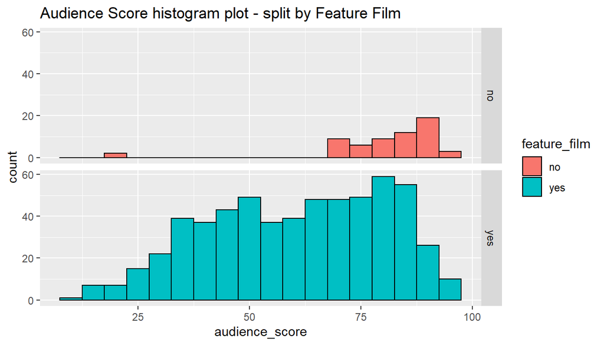

```r
  ggplot(data = movies, aes(x = audience_score, fill = feature_film)) +
  geom_histogram(binwidth=5, color="black") +
  facet_grid(feature_film ~ .) +
  labs(title="Audience Score histogram plot - split by Feature Film")
```

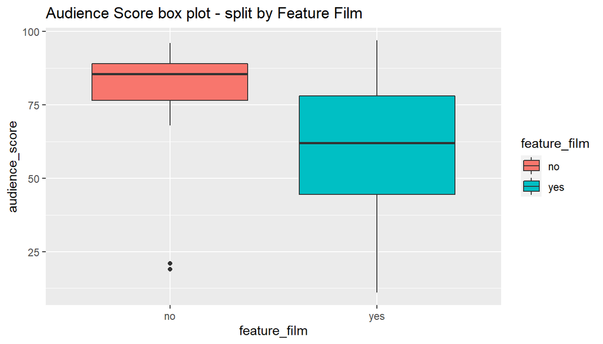

```r
  ggplot(data = movies, aes(x = feature_film, y = audience_score, fill = feature_film)) +
  geom_boxplot() +
  labs(title="Audience Score box plot - split by Feature Film")
```

```r
  movies %>%
  group_by(feature_film) %>%
  summarise(count = n())
```

```
## # A tibble: 2 x 2
##   feature_film count
##   <chr>        <int>
## 1 no              60
## 2 yes            591
```

### Drama Film

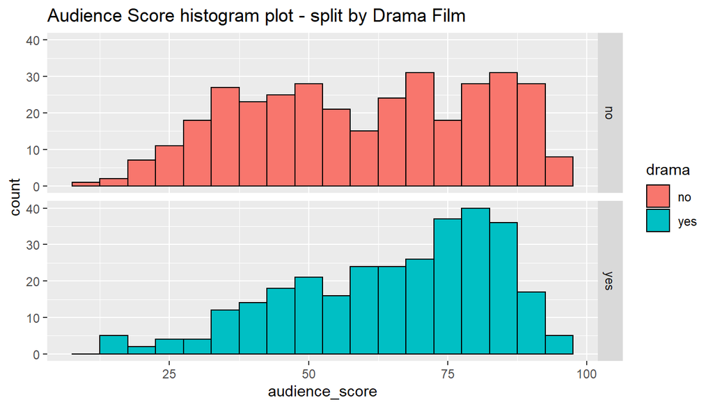

```r
  ggplot(data = movies, aes(x = audience_score, fill = drama)) +
  geom_histogram(binwidth=5, color="black") +
  facet_grid(drama ~ .) +
  labs(title="Audience Score histogram plot - split by Drama Film")
```

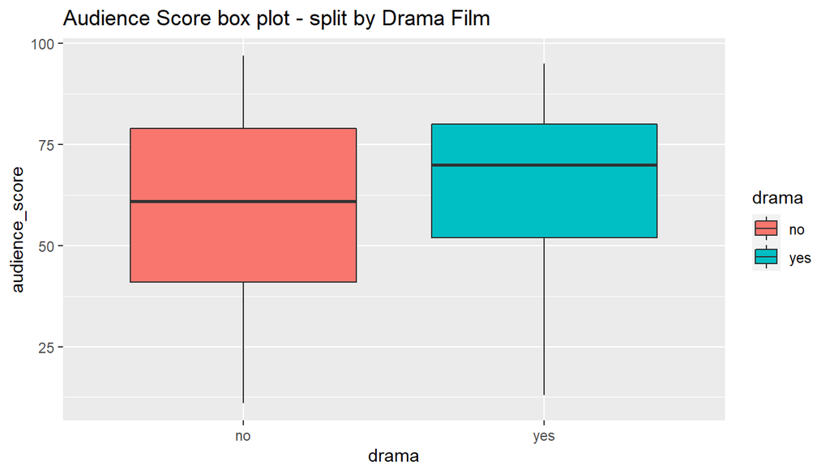

```r
  ggplot(data = movies, aes(x = drama, y = audience_score, fill = drama)) +
  geom_boxplot() +
  labs(title="Audience Score box plot - split by Drama Film")
```

```r
  movies %>%
  group_by(drama) %>%
  summarise(count = n())
```

```
## # A tibble: 2 x 2
##   drama count
##   <chr> <int>
## 1 no      346
## 2 yes     305
```

### Rated R Film

The below plot shows the histogram distributions of audience score, split by the mpaa_rating_R variable. There is not noticeably huge differences between the histogram and box plots, suggesting that this variable may not be a good indicator for audience score. The numerical summary confirms that there are similar amounts of R rated movies as non R rated movies in the sample.

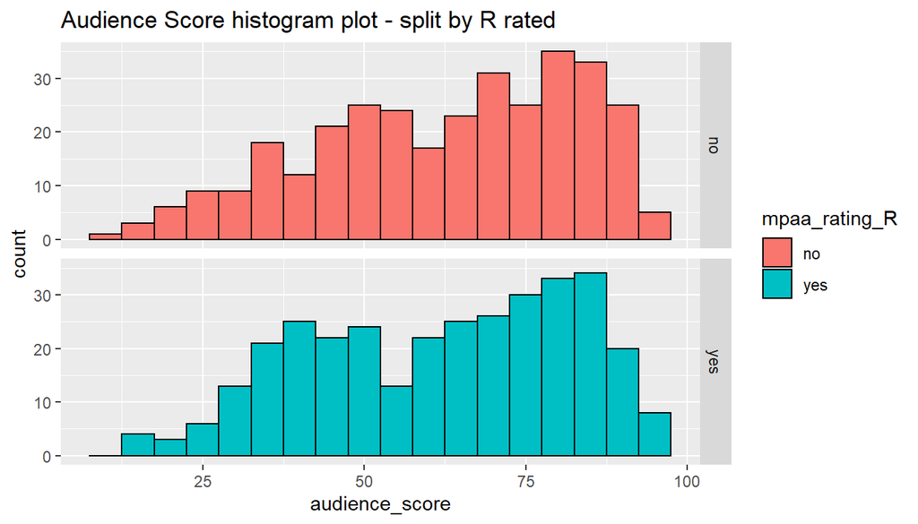

```r
  ggplot(data = movies, aes(x = audience_score, fill = mpaa_rating_R)) +
  geom_histogram(binwidth=5, color="black") +
  facet_grid(mpaa_rating_R ~ .) +
  labs(title="Audience Score histogram plot - split by R rated")
```

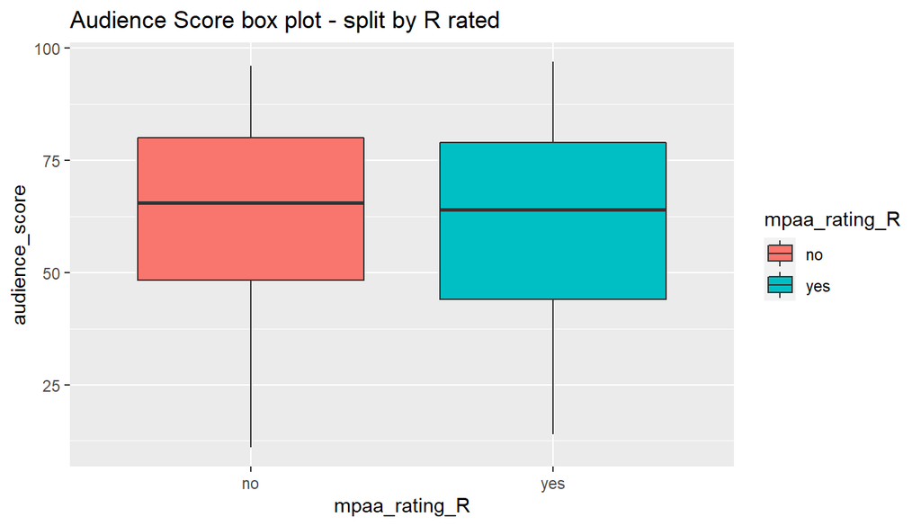

```r
  ggplot(data = movies, aes(x = mpaa_rating_R, y = audience_score, fill = mpaa_rating_R)) +
  geom_boxplot() +
  labs(title="Audience Score box plot - split by R rated")
```

```r
  movies %>%
  group_by(mpaa_rating_R) %>%
  summarise(count = n())
```

```
## # A tibble: 2 x 2
##   mpaa_rating_R count
##   <chr>         <int>
## 1 no              322
## 2 yes             329
```

### Oscar Season Film

The below plot shows the histogram distributions of audience score, split by the oscar season variable. As perhaps expected, we can see that more of the data were released outside of oscar season, with oscar season being a smaller proportion of the year. There are not huge differences in the distributions; we can see with oscar season movies, there is a trough at scores just over 50 that is not evident in the non oscar season movies. There is a peak in the non oscar season movies around a score of 80 that is not evident in oscar season movies.The boxplot shows us that the median oscar season movie slightly outscored the median non oscar season movie, but this difference may not be significant. The numerical summary confirms the number of oscar season movies in the sample is less than thenumber of non oscar season movies.

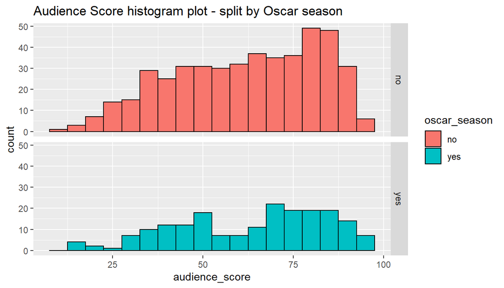

```r
  ggplot(data = movies, aes(x = audience_score, fill = oscar_season)) +
  geom_histogram(binwidth=5, color="black") +
  facet_grid(oscar_season ~ .) +
  labs(title="Audience Score histogram plot - split by Oscar season")
```

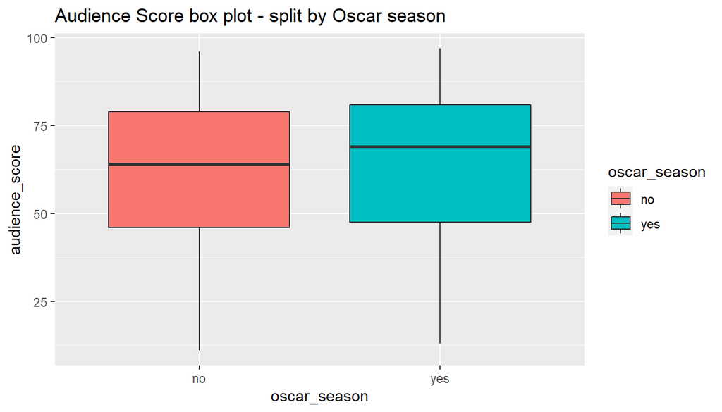

```r
  ggplot(data = movies, aes(x = oscar_season, y = audience_score, fill = oscar_season)) +
  geom_boxplot() +
  labs(title="Audience Score box plot - split by Oscar season")
```

```r
  movies %>%
  group_by(oscar_season) %>%
  summarise(count = n())
```

```
## # A tibble: 2 x 2
##   oscar_season count
##   <chr>        <int>
## 1 no             460
## 2 yes            191
```

### Summer Season Film

The below plot shows the histogram distributions of audience score, split by the summer season variable. As perhaps expected, we can see that more of the data were released outside of summer season, with summer season being a smaller proportion of the year. The most noticeable difference in the distributions is that the peak in scores around 80 is evident in the non summer season movies, but not evident in the summer season movies.The box plots are very similar, ad the numerical summary confirms that we have more than twice as much films in the sample released outside of the summer season.

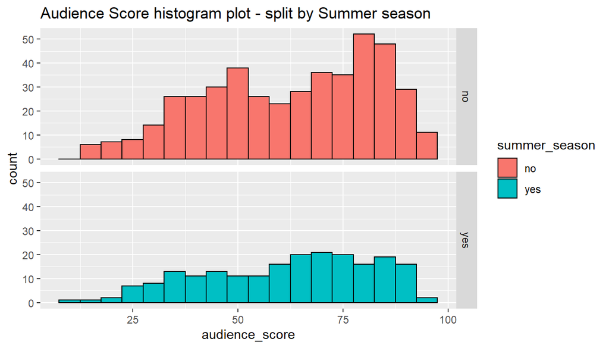

```r
  ggplot(data = movies, aes(x = audience_score, fill = summer_season)) +
  geom_histogram(binwidth=5, color="black") +
  facet_grid(summer_season ~ .) +
  labs(title="Audience Score histogram plot - split by Summer season")
```

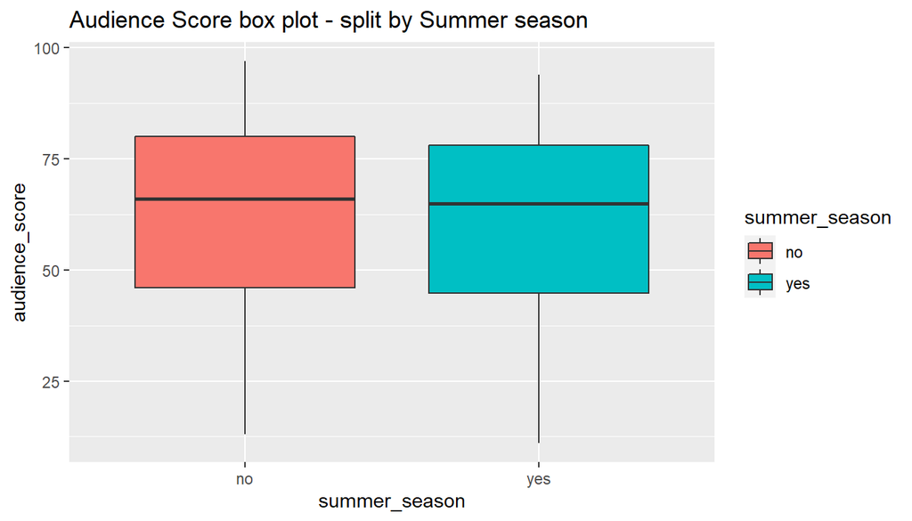

```r
  ggplot(data = movies, aes(x = summer_season, y = audience_score, fill = summer_season)) +
  geom_boxplot() +
  labs(title="Audience Score box plot - split by Summer season")
```

```r
  movies %>%
  group_by(summer_season) %>%
  summarise(count = n())
```

```
## # A tibble: 2 x 2
##   summer_season count
##   <chr>         <int>
## 1 no              443
## 2 yes             208
```

## Part 4: Modeling

### The Model

First we will reduce the dataset to those variables that we will consider for the model. We will remove any rows of data with N/A entries. We will first build a model with all variables included as exlanatory variables, excluding of course the response variable audience_score. The Bayesian Information Criterion (BIC) output below gives ~ 4934.

```r
  movies <- dplyr::select(movies, audience_score, feature_film, drama, runtime, mpaa_rating_R, thtr_rel_year, oscar_season, summer_season, imdb_rating, imdb_num_votes, critics_score, best_pic_nom, best_pic_win, best_actor_win, best_actress_win, best_dir_win, top200_box)

movies <- na.omit(movies)

model_audience_score_full <- lm(audience_score ~ . - audience_score, data = movies)

tidy(model_audience_score_full)
```

```
## # A tibble: 17 x 5
##    term                    estimate   std.error statistic  p.value
##    <chr>                      <dbl>       <dbl>     <dbl>    <dbl>
##  1 (Intercept)         124.         77.5            1.61  1.09e- 1
##  2 feature_filmyes      -2.25        1.69          -1.33  1.83e- 1
##  3 dramayes              1.29        0.877          1.47  1.41e- 1
##  4 runtime              -0.0561      0.0242        -2.32  2.04e- 2
##  5 mpaa_rating_Ryes     -1.44        0.813         -1.78  7.60e- 2
##  6 thtr_rel_year        -0.0766      0.0383        -2.00  4.63e- 2
##  7 oscar_seasonyes      -0.533       0.997         -0.535 5.93e- 1
##  8 summer_seasonyes      0.911       0.949          0.959 3.38e- 1
##  9 imdb_rating          14.7         0.607         24.3   2.03e-92
## 10 imdb_num_votes        0.00000723  0.00000452     1.60  1.10e- 1
## 11 critics_score         0.0575      0.0222         2.59  9.73e- 3
## 12 best_pic_nomyes       5.32        2.63           2.02  4.33e- 2
## 13 best_pic_winyes      -3.21        4.61          -0.697 4.86e- 1
## 14 best_actor_winyes    -1.54        1.18          -1.31  1.91e- 1
## 15 best_actress_winyes  -2.20        1.30          -1.69  9.23e- 2
## 16 best_dir_winyes      -1.23        1.73          -0.713 4.76e- 1
## 17 top200_boxyes         0.848       2.78           0.305 7.61e- 1
```

```r
BIC(model_audience_score_full)
```

```
## [1] 4934.145
```

To minimise the BIC and thus improve the model, we will use the stepAIC function to iterate through the model removing variables to improve the fit of the model. Below we can see that the function discovers the best model has the explanatory variables:

runtime  
critics_score  
imdb_rating

This model gives a BIC of ~ 4872 which we can see is less than the base model. We can also see from the model summary that it gives an adjusted R^2 of 0.7538, which is strong correlation under the frequentist approach.

```r
n = length(movies$audience_score)
k = log(n)

movies_full_step = stepAIC(model_audience_score_full, k=k, data =movies)
```

```
## Start:  AIC=3083.05
## audience_score ~ (feature_film + drama + runtime + mpaa_rating_R +
##     thtr_rel_year + oscar_season + summer_season + imdb_rating +
##     imdb_num_votes + critics_score + best_pic_nom + best_pic_win +
##     best_actor_win + best_actress_win + best_dir_win + top200_box) -
##     audience_score
##
##                    Df Sum of Sq    RSS    AIC
## - top200_box        1         9  62999 3076.7
## - oscar_season      1        28  63018 3076.9
## - best_pic_win      1        48  63038 3077.1
## - best_dir_win      1        51  63040 3077.1
## - summer_season     1        92  63081 3077.5
## - best_actor_win    1       171  63160 3078.3
## - feature_film      1       177  63166 3078.4
## - drama             1       216  63206 3078.8
## - imdb_num_votes    1       255  63244 3079.2
## - best_actress_win  1       283  63273 3079.5
## - mpaa_rating_R     1       314  63304 3079.8
## - thtr_rel_year     1       397  63386 3080.7
## - best_pic_nom      1       408  63398 3080.8
## - runtime           1       538  63527 3082.1
## <none>                           62990 3083.0
## - critics_score     1       669  63659 3083.4
## - imdb_rating       1     58556 121545 3503.8
##
## Step:  AIC=3076.67
## audience_score ~ feature_film + drama + runtime + mpaa_rating_R +
##     thtr_rel_year + oscar_season + summer_season + imdb_rating +
##     imdb_num_votes + critics_score + best_pic_nom + best_pic_win +
##     best_actor_win + best_actress_win + best_dir_win
##
##                    Df Sum of Sq    RSS    AIC
## - oscar_season      1        26  63025 3070.5
## - best_pic_win      1        49  63047 3070.7
## - best_dir_win      1        52  63051 3070.7
## - summer_season     1        94  63093 3071.2
## - best_actor_win    1       169  63168 3071.9
## - feature_film      1       176  63175 3072.0
## - drama             1       214  63213 3072.4
```

[output cut: 186 more lines]

```
##                 Df Sum of Sq    RSS    AIC
## - mpaa_rating_R  1       361  65126 3020.5
## - runtime        1       638  65403 3023.3
## <none>                        64765 3023.4
## - critics_score  1      1027  65792 3027.1
## - imdb_rating    1     68173 132937 3484.3
##
## Step:  AIC=3020.53
## audience_score ~ runtime + imdb_rating + critics_score
##
##                 Df Sum of Sq    RSS    AIC
## <none>                        65126 3020.5
## - runtime        1       653  65779 3020.5
## - critics_score  1      1073  66199 3024.7
## - imdb_rating    1     67874 133000 3478.2
```

```r
summary(movies_full_step)
```

```
##
## Call:
## lm(formula = audience_score ~ runtime + imdb_rating + critics_score,
##     data = movies)
##
## Residuals:
##     Min      1Q  Median      3Q     Max
## -26.998  -6.565   0.557   5.475  52.448
##
## Coefficients:
##                Estimate Std. Error t value Pr(>|t|)
## (Intercept)   -33.28321    3.21939 -10.338  < 2e-16 ***
## runtime        -0.05362    0.02107  -2.545  0.01117 *
## imdb_rating    14.98076    0.57735  25.947  < 2e-16 ***
## critics_score   0.07036    0.02156   3.263  0.00116 **
## ---
## Signif. codes:  0 '***' 0.001 '**' 0.01 '*' 0.05 '.' 0.1 ' ' 1
##
## Residual standard error: 10.04 on 646 degrees of freedom
## Multiple R-squared:  0.7549, Adjusted R-squared:  0.7538
## F-statistic: 663.3 on 3 and 646 DF,  p-value: < 2.2e-16
```

```r
BIC(movies_full_step)
```

```
## [1] 4871.623
```

### Bayesian Model Averaging

We will use bayesian model averaging to confirm our model by comparing multiple plausible models. We can see below the top 5 probable models. Model 1 is the model we have previously derived. We can see that imdb_rating and critics_scores are both strong predictors, and are included in all 5 models. Interestingly, model 5 gives a stronger R^2 than model 1 by also including mpaa_rating_R, but it is not a significant improvement, and it is best to have less variables as a parsimonious model. So we will stick with model 1.

```r
bma_movies <- bas.lm(audience_score ~ . -audience_score, data = movies,
                   prior = "BIC",
                   modelprior = uniform())

bma_movies
```

```
##
## Call:
## bas.lm(formula = audience_score ~ . - audience_score, data = movies,
##     prior = "BIC", modelprior = uniform())
##
##
##  Marginal Posterior Inclusion Probabilities:
##           Intercept      feature_filmyes             dramayes
##             1.00000              0.06537              0.04320
##             runtime     mpaa_rating_Ryes        thtr_rel_year
##             0.46971              0.19984              0.09069
##     oscar_seasonyes     summer_seasonyes          imdb_rating
##             0.07506              0.08042              1.00000
##      imdb_num_votes        critics_score      best_pic_nomyes
##             0.05774              0.88855              0.13119
##     best_pic_winyes    best_actor_winyes  best_actress_winyes
##             0.03985              0.14435              0.14128
##     best_dir_winyes        top200_boxyes
##             0.06694              0.04762
```

```r
summary(bma_movies)
```

```
##                     P(B != 0 | Y)    model 1       model 2       model 3
## Intercept              1.00000000     1.0000     1.0000000     1.0000000
## feature_filmyes        0.06536947     0.0000     0.0000000     0.0000000
## dramayes               0.04319833     0.0000     0.0000000     0.0000000
## runtime                0.46971477     1.0000     0.0000000     0.0000000
## mpaa_rating_Ryes       0.19984016     0.0000     0.0000000     0.0000000
## thtr_rel_year          0.09068970     0.0000     0.0000000     0.0000000
## oscar_seasonyes        0.07505684     0.0000     0.0000000     0.0000000
## summer_seasonyes       0.08042023     0.0000     0.0000000     0.0000000
## imdb_rating            1.00000000     1.0000     1.0000000     1.0000000
## imdb_num_votes         0.05773502     0.0000     0.0000000     0.0000000
## critics_score          0.88855056     1.0000     1.0000000     1.0000000
## best_pic_nomyes        0.13119140     0.0000     0.0000000     0.0000000
## best_pic_winyes        0.03984766     0.0000     0.0000000     0.0000000
## best_actor_winyes      0.14434896     0.0000     0.0000000     1.0000000
## best_actress_winyes    0.14128087     0.0000     0.0000000     0.0000000
## best_dir_winyes        0.06693898     0.0000     0.0000000     0.0000000
## top200_boxyes          0.04762234     0.0000     0.0000000     0.0000000
## BF                             NA     1.0000     0.9968489     0.2543185
## PostProbs                      NA     0.1297     0.1293000     0.0330000
## R2                             NA     0.7549     0.7525000     0.7539000
## dim                            NA     4.0000     3.0000000     4.0000000
## logmarg                        NA -3615.2791 -3615.2822108 -3616.6482224
##                           model 4       model 5
## Intercept               1.0000000     1.0000000
## feature_filmyes         0.0000000     0.0000000
## dramayes                0.0000000     0.0000000
## runtime                 0.0000000     1.0000000
## mpaa_rating_Ryes        1.0000000     1.0000000
## thtr_rel_year           0.0000000     0.0000000
## oscar_seasonyes         0.0000000     0.0000000
## summer_seasonyes        0.0000000     0.0000000
## imdb_rating             1.0000000     1.0000000
## imdb_num_votes          0.0000000     0.0000000
## critics_score           1.0000000     1.0000000
## best_pic_nomyes         0.0000000     0.0000000
## best_pic_winyes         0.0000000     0.0000000
## best_actor_winyes       0.0000000     0.0000000
## best_actress_winyes     0.0000000     0.0000000
## best_dir_winyes         0.0000000     0.0000000
## top200_boxyes           0.0000000     0.0000000
## BF                      0.2521327     0.2391994
## PostProbs               0.0327000     0.0310000
## R2                      0.7539000     0.7563000
## dim                     4.0000000     5.0000000
## logmarg             -3616.6568544 -3616.7095127
```

### Model Diagnostics

Using the model coefficients summarised below, the actual model can be calculated as:

Audience_score = -33.28320569 + 14.98076157(imdb_rating) + 0.07035672(critics_score) - 0.05361506(runtime)

We calculate the credible intervals for each variable and also plot the posterior distributions of the coefficients of each of our 3 variables in our model.

We use prediction with the BAS functioning to predict the variables that should be included based on “best predictive model”, “Highest probability model”, and “Median probability model”. The BPM & HPM confirm our model selection, whereas MPM excludes the runtime variable.

```r
coef_movies <- coefficients(bma_movies)
coef_movies
```

```
##
##  Marginal Posterior Summaries of Coefficients:
##
##  Using  BMA
##
##  Based on the top  65536 models
##                      post mean   post SD     post p(B != 0)
## Intercept             6.235e+01   3.946e-01   1.000e+00
## feature_filmyes      -1.047e-01   5.643e-01   6.537e-02
## dramayes              1.604e-02   1.939e-01   4.320e-02
## runtime              -2.568e-02   3.118e-02   4.697e-01
## mpaa_rating_Ryes     -3.036e-01   7.032e-01   1.998e-01
## thtr_rel_year        -4.533e-03   1.819e-02   9.069e-02
## oscar_seasonyes      -8.035e-02   3.773e-01   7.506e-02
## summer_seasonyes      8.705e-02   3.831e-01   8.042e-02
## imdb_rating           1.498e+01   7.310e-01   1.000e+00
## imdb_num_votes        2.081e-07   1.313e-06   5.774e-02
## critics_score         6.297e-02   3.028e-02   8.886e-01
## best_pic_nomyes       5.068e-01   1.568e+00   1.312e-01
## best_pic_winyes      -8.503e-03   8.479e-01   3.985e-02
## best_actor_winyes    -2.877e-01   8.318e-01   1.443e-01
## best_actress_winyes  -3.088e-01   9.057e-01   1.413e-01
## best_dir_winyes      -1.195e-01   6.227e-01   6.694e-02
## top200_boxyes         8.648e-02   7.050e-01   4.762e-02
```

```r
confint(coef_movies, subset = c(4,9,11))
```

```
##                              2.5%        97.5%          beta
## Intercept            6.158901e+01 6.314219e+01  6.234769e+01
## feature_filmyes     -6.598520e-01 2.756748e-01 -1.046908e-01
## dramayes             0.000000e+00 0.000000e+00  1.604413e-02
## runtime             -8.353795e-02 0.000000e+00 -2.567772e-02
## mpaa_rating_Ryes    -2.162564e+00 0.000000e+00 -3.036174e-01
## thtr_rel_year       -5.482800e-02 0.000000e+00 -4.532635e-03
## oscar_seasonyes     -1.020366e+00 0.000000e+00 -8.034940e-02
## summer_seasonyes    -8.828472e-03 1.103914e+00  8.704545e-02
## imdb_rating          1.364625e+01 1.654611e+01  1.498203e+01
## imdb_num_votes      -2.022153e-07 1.080229e-06  2.080713e-07
## critics_score        0.000000e+00 1.050982e-01  6.296648e-02
## best_pic_nomyes      0.000000e+00 5.033612e+00  5.068035e-01
## best_pic_winyes      0.000000e+00 0.000000e+00 -8.502836e-03
## best_actor_winyes   -2.671589e+00 0.000000e+00 -2.876695e-01
## best_actress_winyes -2.906637e+00 0.000000e+00 -3.088382e-01
## best_dir_winyes     -1.205753e+00 0.000000e+00 -1.195011e-01
## top200_boxyes        0.000000e+00 0.000000e+00  8.648185e-02
## attr(,"Probability")
## [1] 0.95
## attr(,"class")
## [1] "confint.bas"
```

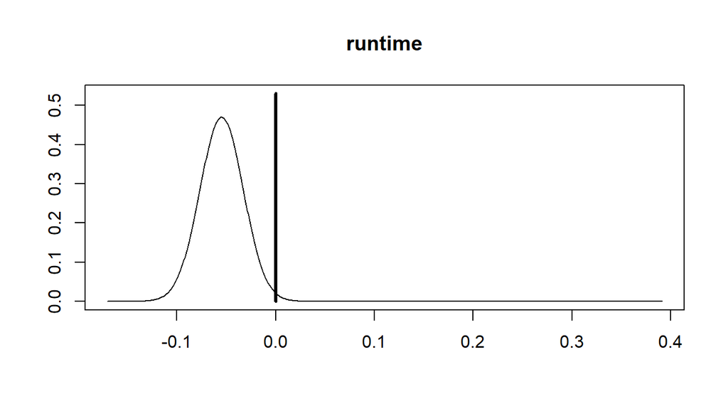

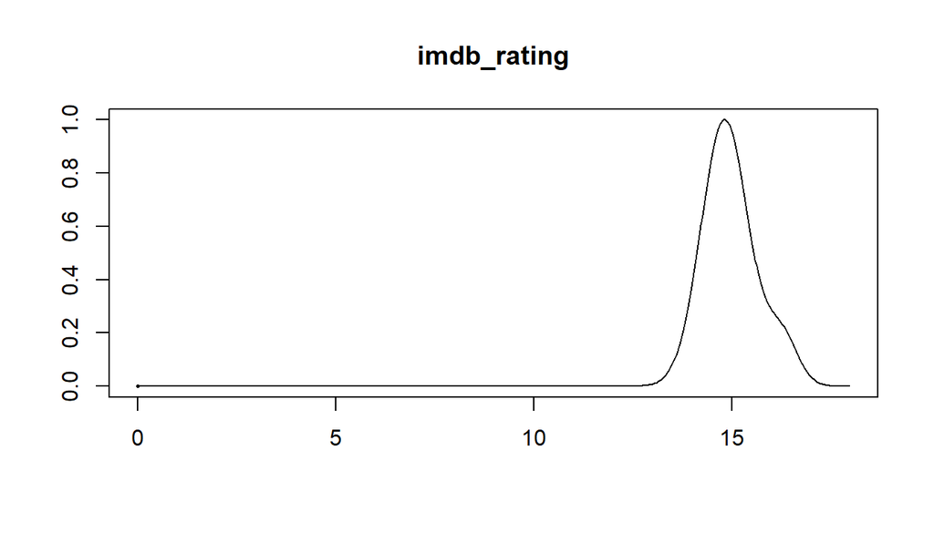

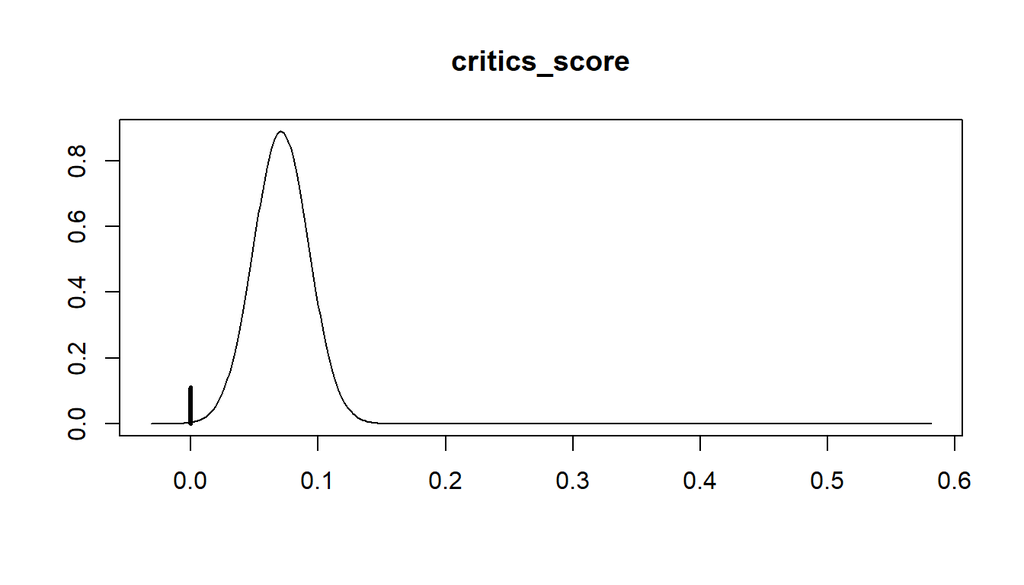

```r
plot(coef_movies, subset = c(4,9,11), ask = FALSE)
```

```r
BPM_pred_movies <- predict(bma_movies, estimator = "BPM", se.fit = TRUE)
variable.names(BPM_pred_movies)
```

```
## [1] "Intercept"     "runtime"       "imdb_rating"   "critics_score"
```

```r
HPM_pred_movies <- predict(bma_movies, estimator = "HPM")
variable.names(HPM_pred_movies)
```

```
## [1] "Intercept"     "runtime"       "imdb_rating"   "critics_score"
```

```r
MPM_pred_movies <- predict(bma_movies, estimator = "MPM")
variable.names(MPM_pred_movies)
```

```
## [1] "Intercept"     "imdb_rating"   "critics_score"
```

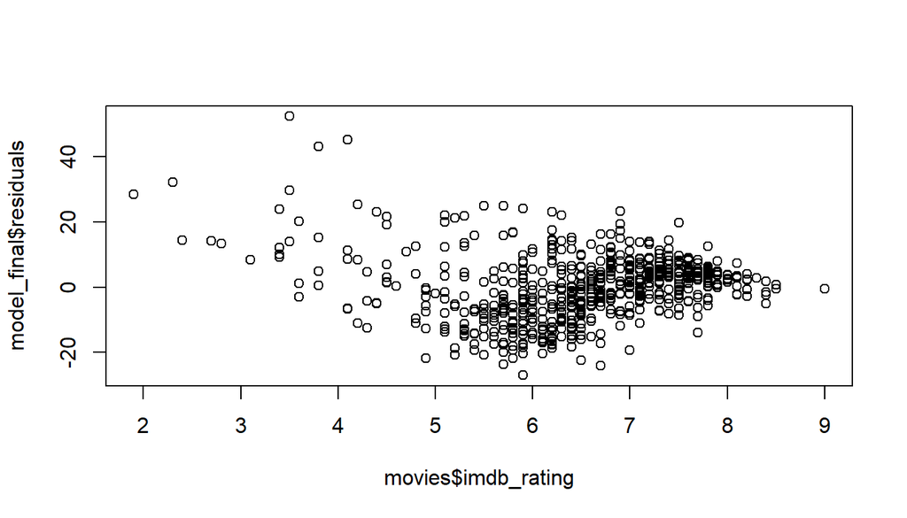

```r
model_final = lm(audience_score ~ imdb_rating + critics_score + runtime, data = movies)
plot(model_final$residuals ~ movies$imdb_rating)
```

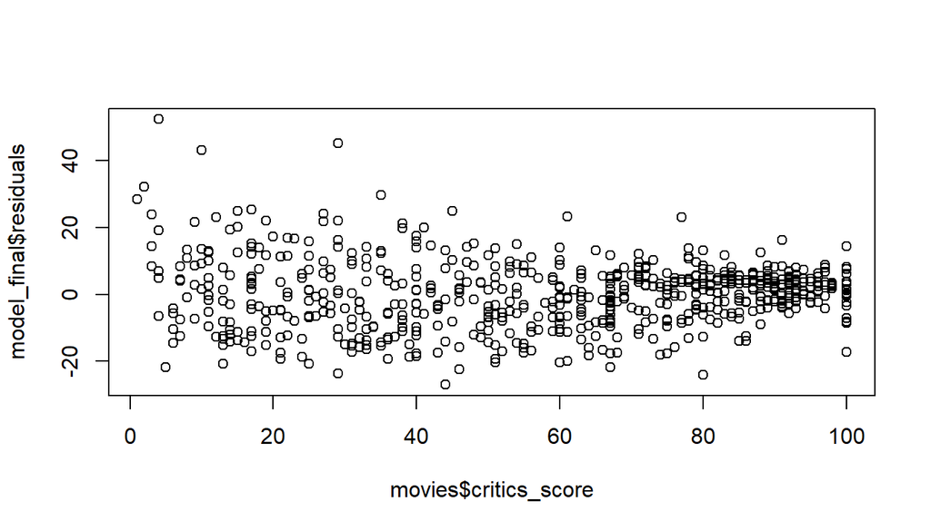

```r
plot(model_final$residuals ~ movies$critics_score)
```

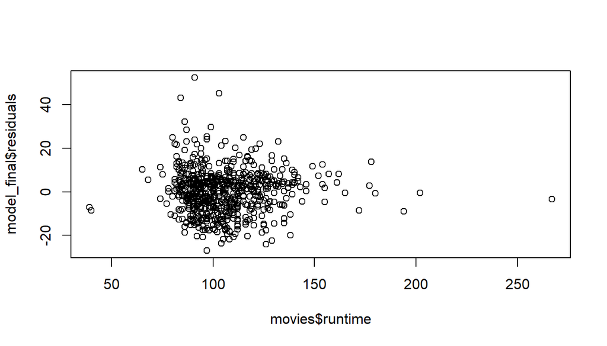

```r
plot(model_final$residuals ~ movies$runtime)
```

Next we will check that the residuals of the model are nearly normal with mean zero. We see in the histogram below that there is some skew. There is a longer right tail because we have some outliers, but we can see that the residuals are approximately centered at zero.

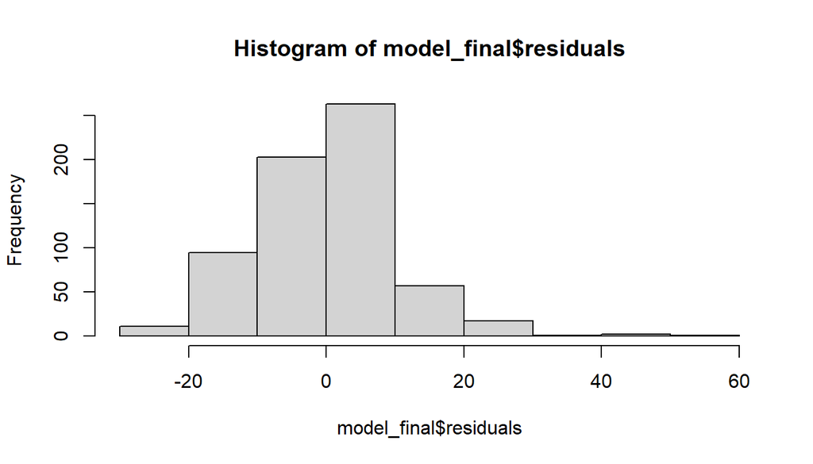

```r
hist(model_final$residuals)
```

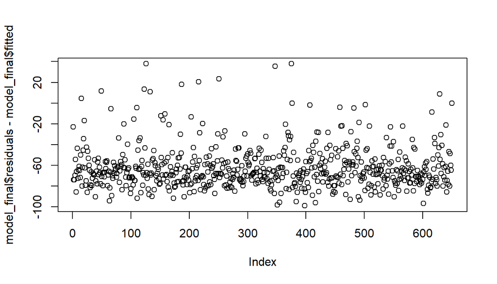

```r
plot(model_final$residuals - model_final$fitted)
```

Lastly, we will check that the residuals are independent. From the residuals plot below, we can see no pattern or trends, therefore we can assume independency.

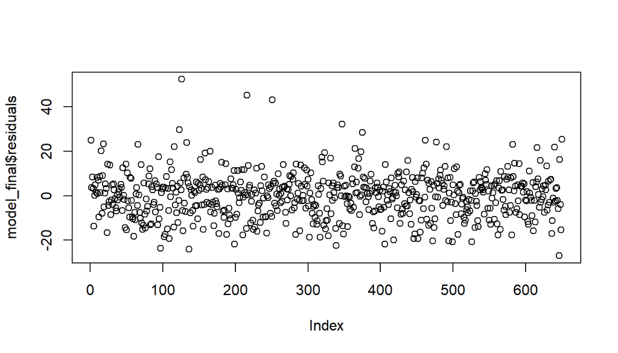

```r
plot(model_final$residuals)
```

A final check for colinearity between the final model variables is shown below. As expected, audience_score has linear relationships with imdb_rating and critics_score. However, there is also a linear relationship between imdb_rating and critics_score. This is evidence of colinearity, and perhaps a better model would only include one of these explanatory variables.

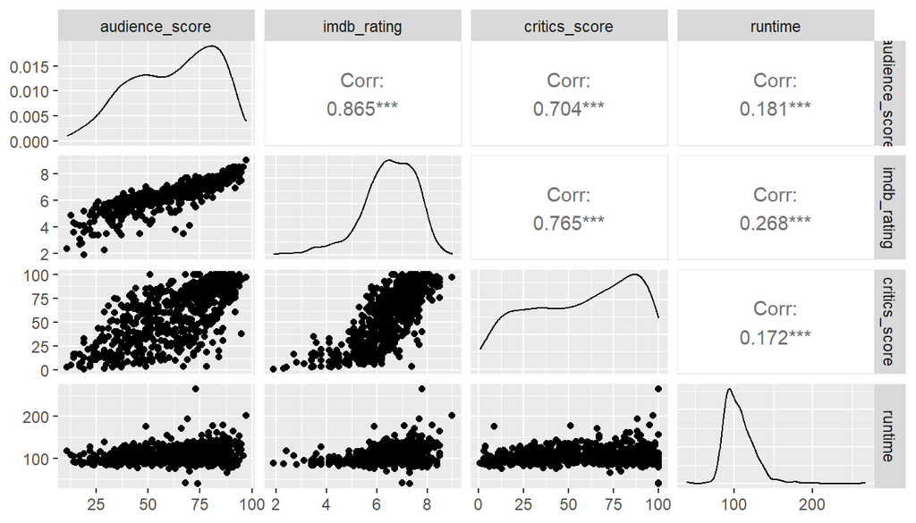

```r
movies_final <- dplyr::select(movies, audience_score, imdb_rating, critics_score, runtime)
ggpairs(movies_final, columns = 1:4)
```

## Part 5: Prediction

2016 movie: London has fallen

imdb_rating: 5.9  
critics_score: 28  
Runtime: 99

References:  
www.imdb.com  
www.rottentomatoes.com

```r
#model prediction
14.98076157*5.9 + 0.0703567251*28 - 0.05361506*99 -33.28320569
```

```
## [1] 51.76538
```

We can do an ANOVA test to find how much of the model’s variability is explained by the model parameters

```r
anova(model_final)
```

```
## Analysis of Variance Table
##
## Response: audience_score
##                Df Sum Sq Mean Sq   F value    Pr(>F)
## imdb_rating     1 198782  198782 1971.7700 < 2.2e-16 ***
## critics_score   1   1167    1167   11.5716  0.000711 ***
## runtime         1    653     653    6.4756  0.011168 *
## Residuals     646  65126     101
## ---
## Signif. codes:  0 '***' 0.001 '**' 0.01 '*' 0.05 '.' 0.1 ' ' 1
```

```r
#imdb_rating
(198782)/(198782+1167+653+65126)
```

```
## [1] 0.7480657
```

```r
#critics_score
(1167)/(198782+1167+653+65126)
```

```
## [1] 0.004391709
```

```r
#runtime
(653)/(198782+1167+653+65126)
```

```
## [1] 0.0024574
```

```r
#R-squared
(198782+1167+653)/(198782+1167+653+65126)
```

```
## [1] 0.7549148
```

## Part 6: Conclusion

To answer the research question, the variables that we have found to provide the best prediction of audience score rating are: imdb rating, critics score, runtime. We can explain to the boss how much each of these variables contribute to the model based on the ANOVA output.

Further testing of movies outside of the original dataset should be conducted to validate the model. With further variables considered, it could be possible to produce a linear model with a better fit.